# ZOMATO

# 1-Problem:

in our project we chose the dataset of the restaurants in Zomato which is an Indian multinational restaurant aggregator and food delivery company. This dataset contains information about various restaurants listed on the platform, including their location, cuisine type, ratings, and other essential attributes.we will study and analyze the restaurants data that will help us identify the preferred cost range and the most likable restaurant type and cuisines type that leads into high ratings to help people who are interested in putting their restaurants on the platform by predicting the ratings of new restaurants on the platform.

# 2-Data Mining Task:

We want to solve this problem by classification data mining task, to predict the highest ratings based on restaurant type, average cost of two people, and the cuisine’s type, by choosing rating as class label.

# 3- Data:

We choose this data from Kaggle website(https://www.kaggle.com/datasets/abhijitdahatonde/zomato-restaurants-dataset) This dataset provides us with information about different type of restaurant and there ratings in food application called Zomato, it consists the following attributes:

Number of attributes:12

[output not shown]

## Missing value

```r
zomato <- read.csv("zomato.csv")
```

```r
summary(zomato)
```

```r
head(zomato)
```

|  | X | Unnamed..0 | restaurant.name | restaurant.type | rate | numofratings | avgCost | online_order | tablebooking | cuisinestype | area | localaddress |
| --- | --- | --- | --- | --- | --- | --- | --- | --- | --- | --- | --- | --- |
| 1 | 0 | 0 | #FeelTheROLL | Quick Bites | 3.4 | 7 | 200 | No | No | Fast Food | Bellandur | Bellandur |
| 2 | 1 | 1 | #L-81 Cafe | Quick Bites | 3.9 | 48 | 400 | Yes | No | Fast Food, Beverages | Byresandra,Tavarekere,Madiwala | HSR |
| 3 | 2 | 2 | #refuel | Cafe | 3.7 | 37 | 400 | Yes | No | Cafe, Beverages | Bannerghatta Road | Bannerghatta Road |
| 4 | 3 | 3 | '@ Biryani Central | Casual Dining | 2.7 | 135 | 550 | Yes | No | Biryani, Mughlai, Chinese | Marathahalli | Marathahalli |
| 5 | 4 | 4 | '@ The Bbq | Casual Dining | 2.8 | 40 | 700 | Yes | No | BBQ, Continental, North Indian, Chinese, Beverages | Bellandur | Bellandur |
| 6 | 5 | 5 | '@99 | Takeaway, Delivery | 3.4 | 37 | 200 | No | No | Mughlai, Biryani, Chinese, North Indian | Whitefield | Whitefield |

```r
print(zomato)
```

[output not shown]

[output cut: 990 more lines]

```r
sum(is.na(zomato))
```

```r
summary(zomato$rate)
```

```r
summary(zomato$numofratings)
```

```r
summary(zomato$avgCost)
```

## Boxplot

```r
boxplot.stats(zomato$rate)$out
```

```r
boxplot.stats(zomato$avgCost)$out
```

```r
boxplot.stats(zomato$numofratings)$out
```

```r
boxplot(zomato$rate)
```

[output not shown]

```r
boxplot(zomato$numofratings)
```

[output not shown]

```r
boxplot(zomato$avgCost)
```

[output not shown]

```r
plot(zomato$rate,zomato$avgCost)
```

[output not shown]

```r
hist(zomato$avgCost)
```

```r
onlineOrder <- table(zomato$online_order)
pie(onlineOrder)
```

## Statistical Measures

```r
summary (zomato$rate)
```

```r
summary(zomato$numofratings)
```

```r
summary(zomato$avgCost)
```

### Check for missing value:

```r
dim(zomato)
```

```r
zomato =na.omit(zomato)
```

```r
dim(zomato)
```

```r
sum(is.na(zomato))
```

### Description:

Missing or null values can significantly impact the effectiveness of a dataset and the quality of insights that can be derived from it. Therefore, we conducted an examination of our data to identify and eliminate any rows containing missing or null values. This process was undertaken to enhance the overall efficiency and reliability of our dataset, ensuring more accurate analysis and valuable information extraction in subsequent steps.

## Detecting and removing the outliers

### Detecting the outliers:

Initially, we detected any unusual data points in the numerical attributes. Subsequently, we removed the rows containing these outliers in order to create a more precise dataset, which would ultimately enhance the accuracy of our later results.

```r
library(outliers)
```

Detect outliers in the ‘numofratings’ column of the ‘zomato’ dataset.

```r
OutN = outlier(zomato$numofratings, logical =TRUE)
```

Sum the number of outliers detected.

```r
sum(OutN)
```

Find the indices of the outliers in the ‘numofratings’ column.

```r
Find_outlier = which(OutN ==TRUE, arr.ind = TRUE)
```

Display the logical vector indicating outliers.

```r
OutN
```

Display the indices of the outliers.

```r
Find_outlier
```

#### Remove rows with outliers from the ‘zomato’ dataset.

```r
zomato= zomato[-Find_outlier,]
```

We replicated the procedures outlined in the previous code but with the column avgCost.

```r
OutAv = outlier(zomato$avgCost, logical =TRUE)
sum(OutAv)
```

```r
Find_outlier = which(OutAv ==TRUE, arr.ind = TRUE)
OutAv
```

```r
Find_outlier
```

```r
zomato= zomato[-Find_outlier,]
```

## Features selection:

ensure the results are repeatable

```r
set.seed(7)
```

load the library

```r
library(mlbench)
library(caret)
library(caret)
library(randomForest)
```

load the data

```r
zomato$rate <- as.factor(zomato$rate )
```

```r
predictors <- zomato[, -5]  # Excluding the class label (satisfaction)
class_label <- zomato$rate
```

```r
summary(zomato)
```

[output not shown]

```r
importance <- importance(model)

ranked_features <- sort(importance[, "MeanDecreaseGini"], decreasing = TRUE)
```

```r
barplot(ranked_features, horiz = TRUE, col = c("lightblue2"), las = 1, main = "Airline satisfaction Variable Import")
```

```r
control <- rfeControl(functions=rfFuncs, method="cv", number=10)
```

```r
results <- rfe(zomato[,11:11], zomato[,12], sizes=c(1:11), rfeControl=control)
```

```r
print(results)
```

```r
predictors(results)
```

```r
plot(results, type=c("g", "o"))
```

### balance

```r
library(ROSE)
```

```r
zomato$rate <- as.factor(zomato$rate)
zomato<-upSample(zomato[,-5],zomato$rate, yname="rate")
plot(zomato$rate)
```

```r
prop.table(table(zomato$rate))
```

```r
title(main="Data after oversampling", xlab="rate", ylab="observations")
```

## Clustring

#### numeric data and scaling

```r
numeric_data <- zomato[sapply(zomato, is.numeric)]
colMeans(numeric_data, na.rm = TRUE)

numeric_data <- scale(numeric_data)
```

```r
set.seed(8953)
library(ggplot2)
library(factoextra)
```

```r
k2<- kmeans(numeric_data,centers = 2, nstart = 20)
str(k2)
fviz_cluster(k2,data = numeric_data)
```

```r
k5<- kmeans(numeric_data,centers = 5, nstart = 20)
str(k5)
fviz_cluster(k5,data = numeric_data)
```

[output not shown]

```r
k8<- kmeans(numeric_data,centers = 8, nstart = 20)
str(k8)
fviz_cluster(k8,data = numeric_data)
```

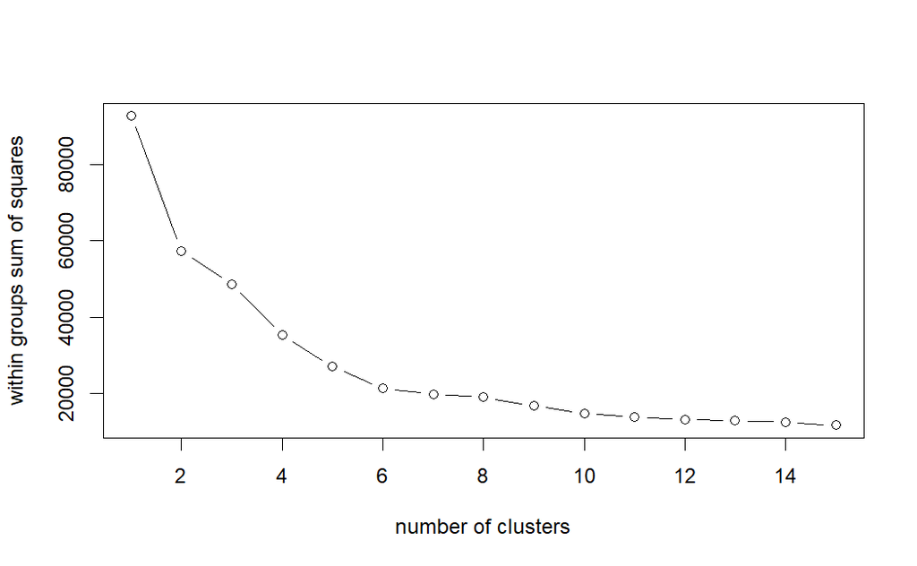

```r
##elbow
wssplot<- function (data, nc=15 ,seed=1234)
{
  wss<-(nrow(data)-1)*sum(apply(data,2,var))
  for(i in 2:nc){
    set.seed(seed)
    wss[i] <- sum(kmeans(data,centers = i)$withinss)}
  plot(1:nc,wss, type="b", xlab="number of clusters", ylab="within groups sum of squares")
}

wssplot(numeric_data)
```

```r
fviz_nbclust(numeric_data, # data
             kmeans, # clustering algorithm
             method = "silhouette") # silhouette
```

```r
fviz_nbclust(numeric_data, # data
             kmeans, # clustering algorithm
             nstart = 25, # if centers is a number, how many random sets should be chosen?(default is 25)
             iter.max = 200, # the maximum number of iterations allowed.
             method = "wss") # elbow method
```

```r
cluster_assignments <- c(k5$cluster)
ground_truth_labels <- c(zomato$rate)
data <- data.frame(cluster = cluster_assignments, label = ground_truth_labels)


# Function to calculate BCubed precision and recall
calculate_bcubed_metrics <- function(data) {
  n <- nrow(data)
  precision_sum <- 0
  recall_sum <- 0

  for (i in 1:n) {
    cluster <- data$cluster[i]
    label <- data$label[i]

    # Count the number of items from the same category within the same cluster
    same_category_same_cluster <- sum(data$label[data$cluster == cluster] == label)

    # Count the total number of items in the same cluster
    total_same_cluster <- sum(data$cluster == cluster)

    # Count the total number of items with the same category
    total_same_category <- sum(data$label == label)

    # Calculate precision and recall for the current item and add them to the sums
    precision_sum <- precision_sum + same_category_same_cluster /total_same_cluster
    recall_sum <- recall_sum + same_category_same_cluster / total_same_category
  }

  # Calculate average precision and recall
  precision <- precision_sum / n
  recall <- recall_sum / n

  return(list(precision = precision, recall = recall))
}

# Calculate BCubed precision and recall
metrics <- calculate_bcubed_metrics(data)

# Extract precision and recall from the metrics
precision <- metrics$precision
recall <- metrics$recall

# Print the results
cat("BCubed Precision:", precision, "\n")
cat("BCubed Recall:", recall, "\n")
```

[output not shown]